# Project 1

2024-09-26

## Introduction

My data set is the pride index data set. It includes US college and university LGBTQ+ pride index ratings (1 - 5 scale for LGBTQ-inclusive policies, programs and practices), along with number of students enrolled, surrounding community size, and characteristics of the campus.

My outcome variable of interest is the pride index rating and the predictors are the community, numbers of students, and the college type. You can get more information about this [here](https://campusprideindex.org)!

[figure not shown]

```r
Project1_PrideIndex <- read.csv('Project1_PrideIndex.csv')
prideindex <- Project1_PrideIndex
library(ggplot2)
```

https://www.bentley.edu/news/bentley-earns-high-marks-national-list-inclusive-lgbtq-campuses

## Univariate Distribution of Outcome Variable

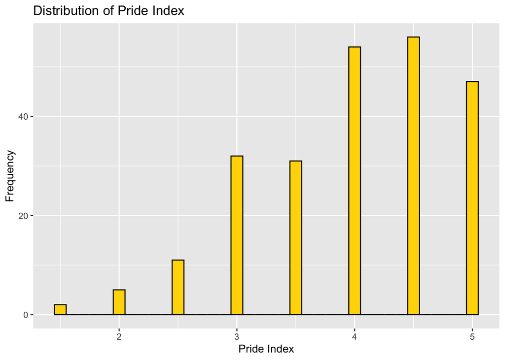

```r
prideindex_ggplot <- ggplot(prideindex)
prideindex_ggplot +
  geom_histogram(aes(x = rating), binwidth = 0.1, fill = "gold", color = "black") +
  labs(
    title = 'Distribution of Pride Index',
    x = 'Pride Index',
    y = 'Frequency'
  )
```

```r
summary(prideindex$rating)
```

```
##    Min. 1st Qu.  Median    Mean 3rd Qu.    Max.
##   1.500   3.500   4.000   3.983   4.500   5.000
```

The mean of the Pride rating around the different campuses is around 3.983 and the median Pride rating is 4. Both the mean and median are in the higher ratings out of 5, proving that most campuses in the US have LGBTQ supporting policies and programs.

## Bivariate Distribution Analyses

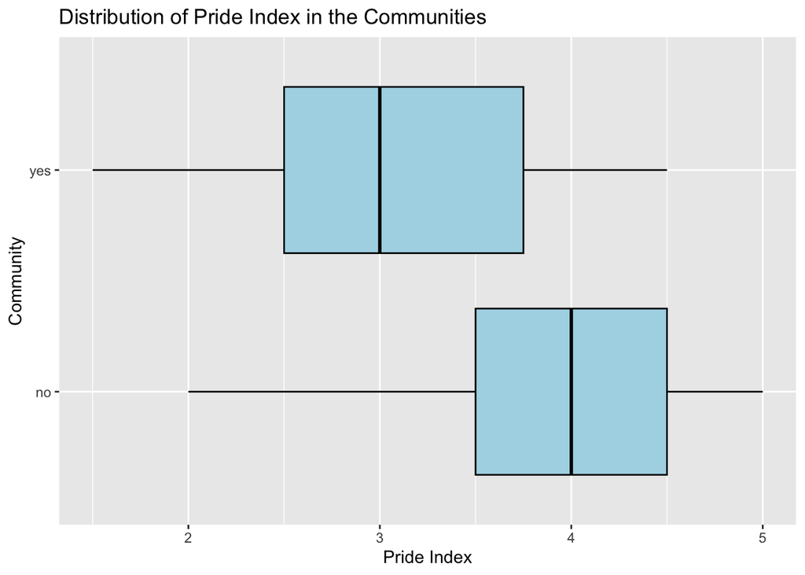

```r
prideindex_ggplot <- ggplot(prideindex)
prideindex_ggplot +
  geom_boxplot(aes(x = rating, y = community),
               color = "black",
               fill = "lightblue"
  ) +
  labs(
    title = 'Distribution of Pride Index in the Communities',
    x = 'Pride Index',
    y = 'Community'
  )
```

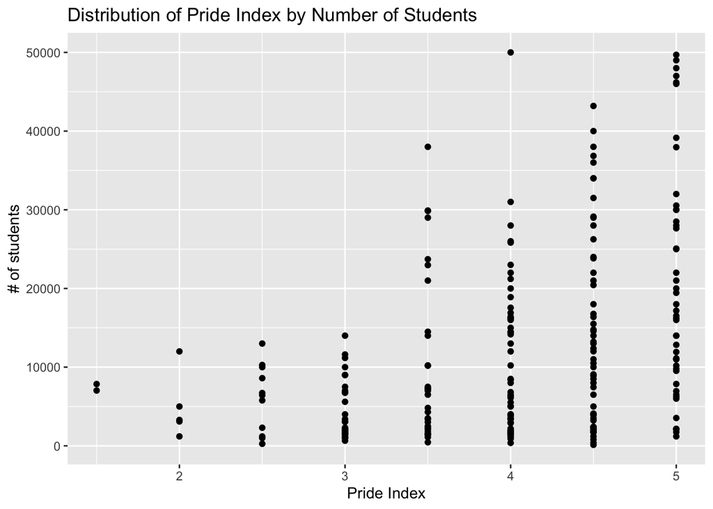

```r
prideindex_ggplot <- ggplot(prideindex)
prideindex_ggplot +
  geom_point(aes(x = rating, y= students)) +
  labs(
    title = 'Distribution of Pride Index by Number of Students',
    x = 'Pride Index',
    y = '# of students',
  )
```

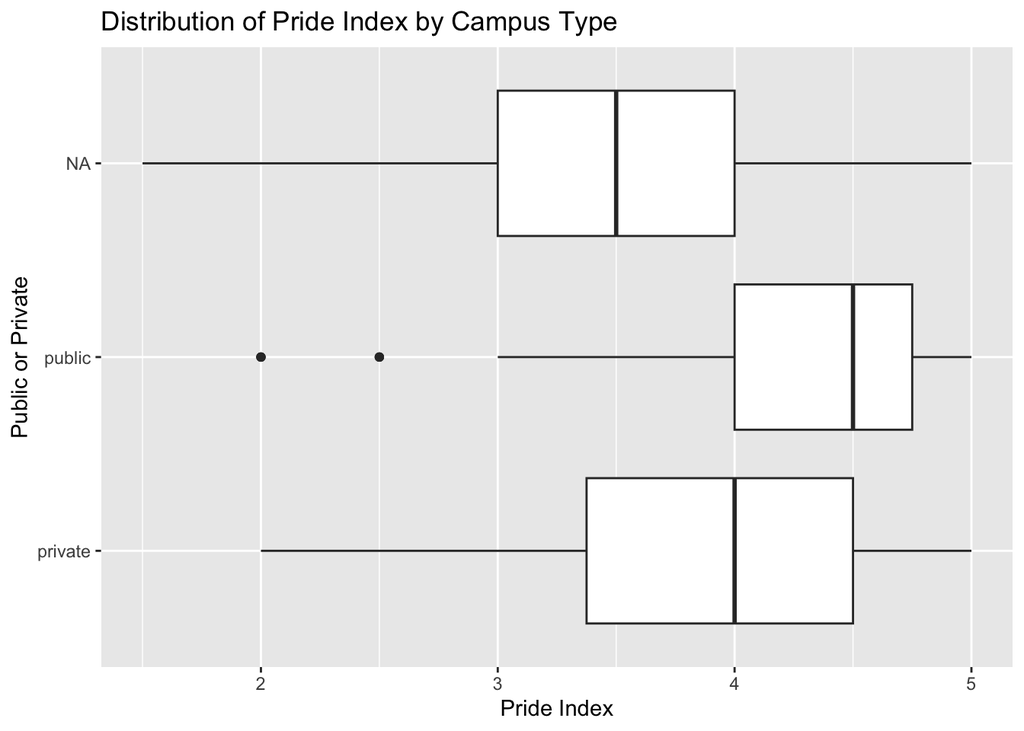

```r
prideindex_ggplot <- ggplot(prideindex)
prideindex_ggplot +
  geom_boxplot(aes(x = rating, y= campus_type)) +
  labs(
    title = 'Distribution of Pride Index by Campus Type',
    x = 'Pride Index',
    y = 'Public or Private'
  )
```